# Student Success - final project

Jemma Marcus-Shi & Linjie Zhu

29 October, 2023

# 1 Project Statement

The purpose of our project is to help Mr. Kirk Bogard, Associate Vice President for Development and External Relations, raise funds for Farmer School of Business. We will create several graphs and maps to clearly show the distribution of FSB recent graduates in the US to indicate where it may be most valuable to try and build external relationships. The audience of our project are shared work producers including Mr. Bogard and his team of people who do the same job as Mr. Kirk Bogard, users who need to know how it is done, and how to do it better.

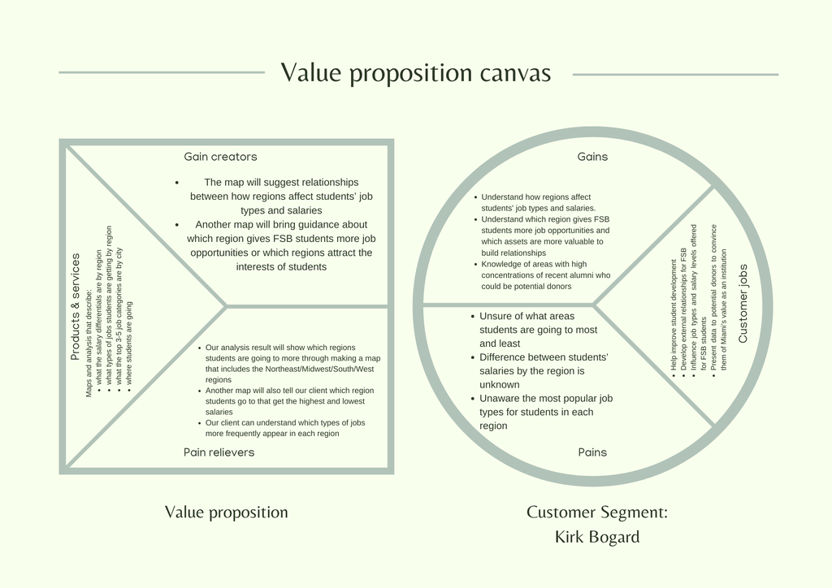

# 2 Clean Data

## 2.1 Data Description

We have three years of data representing FSB graduates in 2019, 2020, and 2021. The dataset provided had 42 variables. The source is either derived by Professor Jones-Farmer during data cleaning/merging, from the Oracle Business Intelligence Enterprise Edition (OBIEE) maintained by Miami administration, or from the self reported senior survey. The files have been cleaned and merged into one file.

The meaning of the columns in the datafile are as follows:

* nmajor: numeric,derived, the number of majors

* major1: text, OBIEE, first major

* major 2: text, OBIEE, second major

* BBRJ: binary, OBIEE, an attribute of a student, but we do not know what this stands for

* Business Direct Admit: binary, OBIEE, a direct admit to FSB as a first year

* Combined Cacc and Masters: binary, OBIEE, combined degree student

* Dean’s List: binary, OBIEE, achieve dean’s list status at least once

* First Generation College Stdnt: binary, OBIEE, first generation student status

* FSB Scholars: binary, OBIEE, FSB scholars program

* Honors Program: binary, OBIEE, member of University honors program

* President’s list: binary, OBIEE, achieved president’s list at least once

* Study Abroad Courtesy Account: binary, OBIEE, do not know meaning

* Transfer Work: binary, OBIEE, do not know exact meaning

* Cum Laude: binary, OBIEE, graduated Cum Laude

* Magna Cum Laude: binary, OBIEE, graduated Magna Cum Laude

* Summa Cum Laude: binary, OBIEE, graduated Summa Cum Laude

* University Honors: binary, OBIEE, graduated with University Honors

* University Honors w/Distinction: binary, OBIEE, graduated with University Honors with Distinction

* minor1: text, OBIEE, first listed minor

* minor2: text, OBIEE, second listed minor

* IPEDS.Race.Ethnicity: text, OBIEE, race/ethnicity

* Gender: text, OBIEE, sex

* GPA.Range: text, OBIEE, GPA within a .5 range

* Term.Code: numeric, OBIEE, First four digits are the graduation year (beginning in July, e.g. July 2020 is FY 2021). Last two digits is the term (10=fall, 15=winter, 20=spring, 30=summer).

* Year.x: text, derived, first four digits of Term.Code stored as a character variable

* latin_honors: text, survey, latin honors designation

* survey_city: text, survey, student reported city in which their job is located

* survey_company: text, survey, student reported company in which they accepted a job

* survey_deptfunc: text, survey, student reported job function

* survey_gradprogram: text, survey, student reported graduate program they will be attending

* survey_gradschool: text, survey, stuent reported graduate school they will be attending

* survey_internfour: text, survey, student reported fourth internship they held during college

* survey_internthree: text, survey, student reported third internship they held during college

* survey_interntwo: text, survey, student reported second internship they held during college

* survey_internone: text, survey, student reported first internship they held during college

* Survey_internships: text, survey, Student reported number of internships they held during college

* survey_offers: text, survey, student reported number of offers for full time employment received

* survey_plans: text, survey, student reported plans after graduation

* survey_pref_field: text, survey, student reported whether working in preferred field

* survey_pref_loc: text, survey, student reported whether working in preferred location

* survey_salary: numeric, survey, student reported salary

* survey_state: text, survey, student reported state in which job is located

Our group will be using the FSB data on the employment location and salary of graduates in order to find information about geographic trends. The data file includes limited survey data on where students are located for their employment, what students’ salaries are, and the job opportunities for Miami sutdents that existed in different regions between 2019 to 2021.

##### The necessary libraries are loaded into R

```r
library(dplyr)
```

##### The data is loaded and displayed to check the success of the loading

```r
df <- readRDS('FSB_BI_Survey_2019_2021.rds')
head(df)
```

|  | nmajor | major1 | major2 | BBRJ | Business Direct Admit | Combined Bacc and Masters | Dean's List | First Generation College Stdnt | FSB Scholars | Honors Program | President's List | Study Abroad Courtesy Account | Transfer Work (Pre-Banner) | Cum Laude | Magna Cum Laude | Summa Cum Laude | University Honors | UniversityHonors w/Distinction | minor1 | minor2 | IPEDS.Race.Ethnicity | Gender | GPA.Range | Term.Code | year.x | latin_honors | survey_city | survey_company | survey_deptfunc | … |
| --- | --- | --- | --- | --- | --- | --- | --- | --- | --- | --- | --- | --- | --- | --- | --- | --- | --- | --- | --- | --- | --- | --- | --- | --- | --- | --- | --- | --- | --- | --- |
| 1 | 1 | Marketing | none | 0 | 1 | 0 | 0 | 0 | 0 | 0 | 0 | 0 | 0 | 0 | 0 | 0 | 0 | 0 | No Minor | No Minor | Hispanic/Latino | Male | 2.00 - 2.49 | 202015 | 2020 | 0 | NA | NA | NA | … |
| 2 | 1 | Finance | none | 0 | 1 | 0 | 0 | 0 | 0 | 0 | 0 | 0 | 0 | 0 | 0 | 0 | 0 | 0 | Business Legal Studies | No Minor | White | Male | 3.00 - 3.49 | 201920 | 2019 | 0 | Toledo | BAM Nutual | Finance | … |
| 3 | 1 | Marketing | none | 0 | 1 | 0 | 1 | 0 | 0 | 0 | 0 | 0 | 0 | 1 | 0 | 0 | 0 | 0 | Humanities | Humanities | Asian | Female | 3.50 - 4.00 | 202120 | 2021 | 0 | Columbus | CoHatch | General Management | … |
| 4 | 1 | Finance | none | 0 | 1 | 0 | 0 | 1 | 0 | 0 | 0 | 0 | 0 | 0 | 0 | 0 | 0 | 0 | Accountancy | Accountancy | White | Male | 3.00 - 3.49 | 202020 | 2020 | 0 | NA | PwC | NA | … |
| 5 | 1 | Marketing | none | 0 | 1 | 0 | 1 | 0 | 0 | 0 | 0 | 0 | 0 | 0 | 0 | 0 | 0 | 0 | Supply Chain Management | Supply Chain Management | White | Male | 3.00 - 3.49 | 201920 | 2019 | 0 | Columbus | Abercrombie & Fitch | General Management | … |
| 6 | 1 | Marketing | none | 0 | 1 | 0 | 0 | 0 | 0 | 0 | 0 | 0 | 1 | 0 | 0 | 0 | 0 | 0 | Humanities | Humanities | White | Female | 3.00 - 3.49 | 202020 | 2020 | 0 | Cleveland | McDonald's | Consulting Marketing / Sales Operations / Procurement | … |

##### Missing values are evaluated

```r
colSums(is.na(df))
```

```
##                         nmajor                         major1
##                              0                              0
##                         major2                           BBRJ
##                              0                              0
##          Business Direct Admit      Combined Bacc and Masters
##                              0                              0
##                    Dean's List First Generation College Stdnt
##                              0                              0
##                   FSB Scholars                 Honors Program
##                              0                              0
##               President's List  Study Abroad Courtesy Account
##                              0                              0
##     Transfer Work (Pre-Banner)                      Cum Laude
##                              0                              0
##                Magna Cum Laude                Summa Cum Laude
##                              0                              0
##              University Honors UniversityHonors w/Distinction
##                              0                              0
##                         minor1                         minor2
##                              0                              0
##           IPEDS.Race.Ethnicity                         Gender
##                              0                              0
##                      GPA.Range                      Term.Code
##                              0                              0
##                         year.x                   latin_honors
##                              0                              0
##                    survey_city                 survey_company
##                           1315                           1238
##                survey_deptfunc             survey_gradprogram
##                           1739                           3047
##              survey_gradschool              survey_internfour
##                           3023                           3132
##               survey_internone             survey_internships
##                            977                            566
##             survey_internthree               survey_interntwo
##                           2765                           1870
##                  survey_offers                   survey_plans
##                           1004                            579
##              survey_pref_field                survey_pref_loc
##                           1550                           1631
##                  survey_salary                   survey_state
##                           1503                           1297
```

##### Variables are removed due to lack of understanding, missing values, and relevance

```r
# Variables "BBRJ", "Study Abroad Courtesy Account", and "Transfer Work" are removed due to lack of understanding and missing variables

df <- df[, !(names(df) %in% c("BBRJ","Study Abroad Courtesy Account", "Transfer Work (Pre-Banner)"))]

# Variables without relevance to the research question are removed

df <- df[, !(names(df) %in% c("nmajor", "Business Direct Admit", "First Generation College Stdnt", "Combined Bacc and Masters", "Dean's List", "FSB Scholars", "Honors Program", "President's List", "Cum Laude", "Magna Cum Laude", "Summa Cum Laude", "University Honors","UniversityHonors w/Distinction", "year.x", "latin_honors", "survey_gradprogram", "survey_gradschool", "survey_internfour","survey_internone", "survey_internships", "survey_internthree", "survey_interntwo"))]
```

##### The data is displayed again and the dimensions are checked to confirm removal of variables

```r
head(df)
```

|  | major1 | major2 | minor1 | minor2 | IPEDS.Race.Ethnicity | Gender | GPA.Range | Term.Code | survey_city | survey_company | survey_deptfunc | survey_offers | survey_plans | survey_pref_field | survey_pref_loc | survey_salary | survey_state |
| --- | --- | --- | --- | --- | --- | --- | --- | --- | --- | --- | --- | --- | --- | --- | --- | --- | --- |
| 1 | Marketing | none | No Minor | No Minor | Hispanic/Latino | Male | 2.00 - 2.49 | 202015 | NA | NA | NA | NA | seeking continuing education | NA | NA | NA | NA |
| 2 | Finance | none | Business Legal Studies | No Minor | White | Male | 3.00 - 3.49 | 201920 | Toledo | BAM Nutual | Finance | 0 | accepted fulltime job | Yes | Yes | NA | Ohio |
| 3 | Marketing | none | Humanities | Humanities | Asian | Female | 3.50 - 4.00 | 202120 | Columbus | CoHatch | General Management | 1 | accepted fulltime job | Yes | Yes | 40000 | OH |
| 4 | Finance | none | Accountancy | Accountancy | White | Male | 3.00 - 3.49 | 202020 | NA | PwC | NA | NA | accepted fulltime job | NA | NA | NA | NA |
| 5 | Marketing | none | Supply Chain Management | Supply Chain Management | White | Male | 3.00 - 3.49 | 201920 | Columbus | Abercrombie & Fitch | General Management | 1 | accepted fulltime job | Yes | Yes | 63500 | Ohio |
| 6 | Marketing | none | Humanities | Humanities | White | Female | 3.00 - 3.49 | 202020 | Cleveland | McDonald's | Consulting Marketing / Sales Operations / Procurement | 4 | accepted fulltime job | Yes | Yes | 68000 | OH |

```r
dim(df)
```

```
## [1] 3235   17
```

##### Rows that contain a null value for “survey_state” are removed

```r
df <- df[!is.na(df$survey_state), , drop = FALSE]
```

##### Only rows where “accepted fulltime job” is the value in “survey_plans” are kept

```r
df <- df %>% filter(survey_plans == "accepted fulltime job")
```

##### The data is checked for remaining null values

```r
colSums(is.na(df))
```

```
##               major1               major2               minor1
##                    0                    0                    0
##               minor2 IPEDS.Race.Ethnicity               Gender
##                    0                    0                    0
##            GPA.Range            Term.Code          survey_city
##                    0                    0                   17
##       survey_company      survey_deptfunc        survey_offers
##                    8                  444                  220
##         survey_plans    survey_pref_field      survey_pref_loc
##                    0                  270                  329
##        survey_salary         survey_state
##                  216                    0
```

##### Null values are imputed

```r
# Missing values in variables 'survey_city', 'survey_company', and 'survey_deptfunc' are imputed with "Unknown"

df[, c("survey_city", "survey_company", "survey_deptfunc")] <- lapply(df[, c("survey_city", "survey_company", "survey_deptfunc")], function(x) ifelse(is.na(x), "Unknown", x))

# Missing values in variables 'survey_offers', 'survey_pref_field', and 'survey_pref_loc' are imputed with "None"

df[, c("survey_offers", "survey_pref_field", "survey_pref_loc")] <- lapply(df[, c("survey_offers", "survey_pref_field", "survey_pref_loc")], function(x) ifelse(is.na(x), "None", x))

# The missing values in the 'survey_salary' variable are imputed with the mean salary

df$survey_salary[is.na(df$survey_salary)] <- mean(df$survey_salary, na.rm = TRUE)
```

##### The data is checked for remaining null values

```r
colSums(is.na(df))
```

```
##               major1               major2               minor1
##                    0                    0                    0
##               minor2 IPEDS.Race.Ethnicity               Gender
##                    0                    0                    0
##            GPA.Range            Term.Code          survey_city
##                    0                    0                    0
##       survey_company      survey_deptfunc        survey_offers
##                    0                    0                    0
##         survey_plans    survey_pref_field      survey_pref_loc
##                    0                    0                    0
##        survey_salary         survey_state
##                    0                    0
```

##### ‘survey_state’ is converted to uppercase and spaces are removed

```r
df$survey_state <- toupper(df$survey_state)
df$survey_state <- trimws(df$survey_state)
```

##### state names are standardized to abbreviations and countries and cities outside the US are removed

```r
df$survey_state <- recode(df$survey_state,
  'ALABAMA' = 'AL',
  'ALASKA' = 'AK',
  'ARIZONA' = 'AZ',
  'ARKANSAS' = 'AR',
  'CALIFORNIA' = 'CA',
  'COLORADO' = 'CO',
  'CONNECTICUT' = 'CT',
  'DELAWARE' = 'DE',
  'FLORIDA' = 'FL',
  'GEORGIA' = 'GA',
  'IDAHO' = 'ID',
  'ILLINOIS' = 'IL',
  'INDIANA' = 'IN',
  'IOWA' = 'IA',
  'KANSAS' = 'KS',
  'KENTUCKY' = 'KY',
  'LOUISIANA' = 'LA',
  'MAINE' = 'ME',
  'MARYLAND' = 'MD',
  'MASSACHUSETTS' = 'MA',
  'MICHIGAN' = 'MI',
  'MINNESOTA' = 'MN',
  'MISSISSIPPI' = 'MS',
  'MISSOURI' = 'MO',
  'MONTANA' = 'MT',
  'NEBRASKA' = 'NE',
  'NEVADA' = 'NV',
  'NEW HAMPSHIRE' = 'NH',
  'NEW JERSEY' = 'NJ',
  'NEW MEXICO' = 'NM',
  'NEW YORK' = 'NY',
  'NORTH CAROLINA' = 'NC',
  'NORTH DAKOTA' = 'ND',
  'OHIO' = 'OH',
  'OKLAHOMA' = 'OK',
  'OREGON' = 'OR',
  'PENNSYLVANIA' = 'PA',
  'RHODE ISLAND' = 'RI',
  'SOUTH CAROLINA' = 'SC',
  'SOUTH DAKOTA' = 'SD',
  'TENNESSEE' = 'TN',
  'TEXAS' = 'TX',
  'UTAH' = 'UT',
  'VERMONT' = 'VT',
  'VIRGINIA' = 'VA',
  'WASHINGTON' = 'WA',
  'WEST VIRGINIA' = 'WV',
  'WISCONSIN' = 'WI',
  'WYOMING' = 'WY',
  'OH, USA' = 'OH',
  'OHIO/ UNITED STATES' = 'OH',
  'OH/US' = 'OH',
  'OHIO / THE UNITED STATES' = 'OH',
  'OHIO/UNITED STATES' = 'OH',
  'OH, USA' = 'OH',
  'OHIO / USA ' = 'OH',
  'OH/USA' = 'OH',
  'OHIO/UNITED STATES' = 'OH',
  'OHIO / UNITED STATES' = 'OH',
  'OHIO/USA' = 'OH',
  'OH, USA' = 'OH',
  'OHIO / USA' = 'OH',
  'IL/ USA' = 'IL',
  'ILLINOIS / USA' = 'IL',
  'ILLINOIS, USA' = 'IL',
  'ILLINOIS/USA' = 'IL',
  'ILLINOIS/ US' = 'IL',
  'IL, UNITED STATES' = 'IL',
  'IL, US' = 'IL',
  'IL, USA' = 'IL',
  'IL/USA' = 'IL',
  'BELIZE' = 'DELETE',
  'CANADA' = 'DELETE',
  'CHINA' = 'DELETE',
  'FUJIAN PROVINCE' = 'DELETE',
  'INDIA' = 'DELETE',
  'IRELAND' = 'DELETE',
  'MONTENEGRO' = 'DELETE',
  'TBA / USA' = 'DELETE',
  'TURKEY' = 'DELETE',
  'UNITED KINGDOM' = 'DELETE',
  'ZHEJIANG PROVINCE' = 'DELETE',
  'COLORADO/ UNITED STATES' = 'CO',
  'D.C.' = 'DC',
  'DISTRICT OF COLUMBIA' = 'DC',
  'WASHINGTON D.C/UNITED STATES' = 'DC',
  'GEORGIA, USA' = 'GA',
  'IN / USA' = 'IN',
  'MA / USA' = 'MA',
  'MASSACHUSETTS, USA' = 'MA',
  'MI / U.S.' = 'MI',
  'NEW YORK, USA' = 'NY',
  'TEXAS/ USA' = 'TX',
  'TX/USA' = 'TX',
  'UNITED STATES' = 'USA',
  'US' = 'USA',
  'VIRGINIA (VA)' = 'VA',
  'VIRGINIA/ USA' = 'VA',
  'WISCONSIN / USA' = 'WI',
  'MICHIGAN, DETROIT' = 'MI'
)
```

##### Rows with state values marked for deletion are removed

```r
df <- df %>% filter(survey_state != "DELETE")
```

##### 2.1.0.0.1 ‘survey_state’ values are further standardized

```r
df$survey_state <- recode(df$survey_state,
  'COLORADO/ UNITED STATES' = 'CO',
  'D.C.' = 'DC',
  'DISTRICT OF COLUMBIA' = 'DC',
  'WASHINGTON D.C/UNITED STATES' = 'DC',
  'GEORGIA, USA' = 'GA',
  'IN / USA' = 'IN',
  'MA / USA' = 'MA',
  'MASSACHUSETTS, USA' = 'MA',
  'MI / U.S.' = 'MI',
  'NEW YORK, USA' = 'NY',
  'TEXAS/ USA' = 'TX',
  'TX/USA' = 'TX',
  'UNITED STATES' = 'USA',
  'US' = 'USA',
  'VIRGINIA (VA)' = 'VA',
  'VIRGINIA/ USA' = 'VA',
  'WISCONSIN / USA' = 'WI',
  'MICHIGAN, DETROIT' = 'MI'
)
```

##### ‘survey_city’ column is standardized and errors are amended

```r
df$survey_city <- toupper(df$survey_city)
df$survey_city <- trimws(df$survey_city)
```

```r
df$survey_city <- recode(df$survey_city,
  'NEW YORK CITY' = 'NEW YORK',
  'NYC' = 'NEW YORK',
  'CINCINATTI' = 'CINCINNATI',
  'WITCHITA' = 'WICHITA',
  'MILWAUKWEE' = 'MILWAUKEE',
  'CINCINNATI, OH' = 'CINCINNATI')
```

##### Rows with missing values in ‘survey_city’ are removed

```r
df <- df %>% filter(!is.na(survey_city))
```

##### The modified data is saved to a new CSV file

```r
write.csv(df, file = "FSB_Survey.csv", row.names = FALSE)
```

# 3 Explanation of Cleaning the Data

[session information not shown]

We ran the code sessionInfo() function to determine the version of r studio used to ensure our code can be reproduced. We have also saved our original file “FSB_BI_Survey_2019_2021.rds”. Thus, we can rerun the code in the future to ensure reproducibility.

# 5 Dashboard

### 5.0.1 Question 1: Students’ average salary by region/state

We will calculate the average salary for students by state or region, depending on the differences we find after analysis. The graph will only show the 10 states have the highest average salaries since there are too many states.

### 5.0.2 Question 2: City rank by job opportunities

We will summarize the number of students employed by city and rank those cities by frequency. Thus, we can find which cities give our students the most job opportunities. It will also allow our client to be aware of which cities should be the focus of fundraising efforts.

# 6 Region/State by Average Salaries

```r
df <- df %>% mutate(city_state = paste(survey_city, ", ", survey_state))
cities <- cities %>% mutate(city_state = toupper(paste(city, ", ", state_id)))
```

```r
df_final <- left_join(df, cities %>% select(city_state, lat, lng), by = "city_state")
```

```r
head(df_final)
```

|  | major1 | major2 | minor1 | minor2 | IPEDS.Race.Ethnicity | Gender | GPA.Range | Term.Code | survey_city | survey_company | survey_deptfunc | survey_offers | survey_plans | survey_pref_field | survey_pref_loc | survey_salary | survey_state | city_state | lat | lng |
| --- | --- | --- | --- | --- | --- | --- | --- | --- | --- | --- | --- | --- | --- | --- | --- | --- | --- | --- | --- | --- |
| 1 | Finance | none | Business Legal Studies | No Minor | White | Male | 3.00 - 3.49 | 201920 | TOLEDO | BAM Nutual | Finance | 0 | accepted fulltime job | Yes | Yes | 58203.12 | OH | TOLEDO , OH | 41.6638 | -83.5827 |
| 2 | Marketing | none | Humanities | Humanities | Asian | Female | 3.50 - 4.00 | 202120 | COLUMBUS | CoHatch | General Management | 1 | accepted fulltime job | Yes | Yes | 40000.00 | OH | COLUMBUS , OH | 39.9862 | -82.9855 |
| 3 | Marketing | none | Supply Chain Management | Supply Chain Management | White | Male | 3.00 - 3.49 | 201920 | COLUMBUS | Abercrombie & Fitch | General Management | 1 | accepted fulltime job | Yes | Yes | 63500.00 | OH | COLUMBUS , OH | 39.9862 | -82.9855 |
| 4 | Marketing | none | Humanities | Humanities | White | Female | 3.00 - 3.49 | 202020 | CLEVELAND | McDonald's | Consulting Marketing / Sales Operations / Procurement | 4 | accepted fulltime job | Yes | Yes | 68000.00 | OH | CLEVELAND , OH | 41.4764 | -81.6805 |
| 5 | Finance | none | Economics | No Minor | White | Female | 3.50 - 4.00 | 201920 | CHICAGO | Ernst & Young | Analytics\n Consulting | 1 | accepted fulltime job | Yes | Yes | 58000.00 | OH | CHICAGO , OH | NA | NA |
| 6 | Accountancy | none | No Minor | No Minor | White | Male | 3.50 - 4.00 | 202120 | CLEVELAND | EY | Accounting | 1 | accepted fulltime job | Yes | Yes | 53000.00 | OH | CLEVELAND , OH | 41.4764 | -81.6805 |

```r
df %>% count(city_state) %>% arrange(desc(n)) %>% head(10)
```

|  | city_state | n |
| --- | --- | --- |
| 1 | CHICAGO , IL | 500 |
| 2 | CINCINNATI , OH | 233 |
| 3 | COLUMBUS , OH | 185 |
| 4 | CLEVELAND , OH | 131 |
| 5 | NEW YORK , NY | 63 |
| 6 | INDIANAPOLIS , IN | 32 |
| 7 | DENVER , CO | 28 |
| 8 | BOSTON , MA | 26 |
| 9 | PITTSBURGH , PA | 23 |
| 10 | DAYTON , OH | 21 |

```r
grouped_data <- df %>%
  group_by(survey_state) %>%
  summarize(AvgSalary = mean(survey_salary),
            OfferCount = n()) %>%
  filter(OfferCount >= 10)
```

## 6.1 Column

### 6.1.1 Add Bar Charts and/or Scatterplot Map to show Highest Region/State

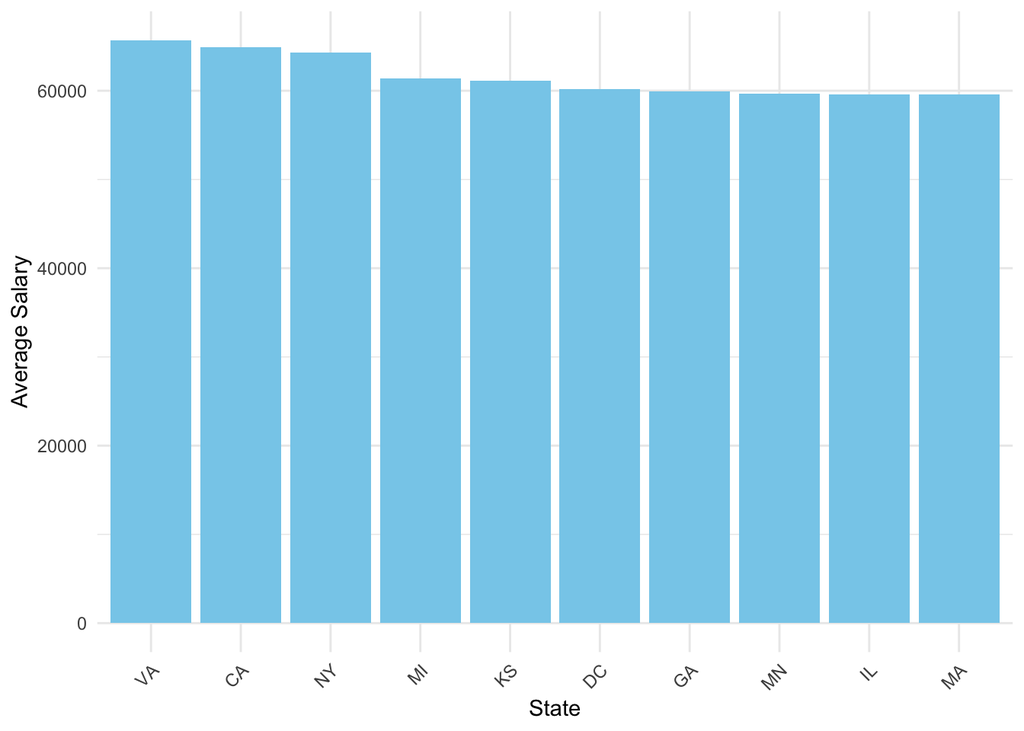

# 7 City Rank by Job Opportunities

```r
offers_by_city <- df_final %>%
  group_by(city_state) %>%
  summarize(Offer_Count = n())

ranked_offers <- offers_by_city %>%
  arrange(desc(Offer_Count)) %>%
  mutate(Rank = row_number())
```

## 7.1 Column

### 7.1.1 Add Bar Charts

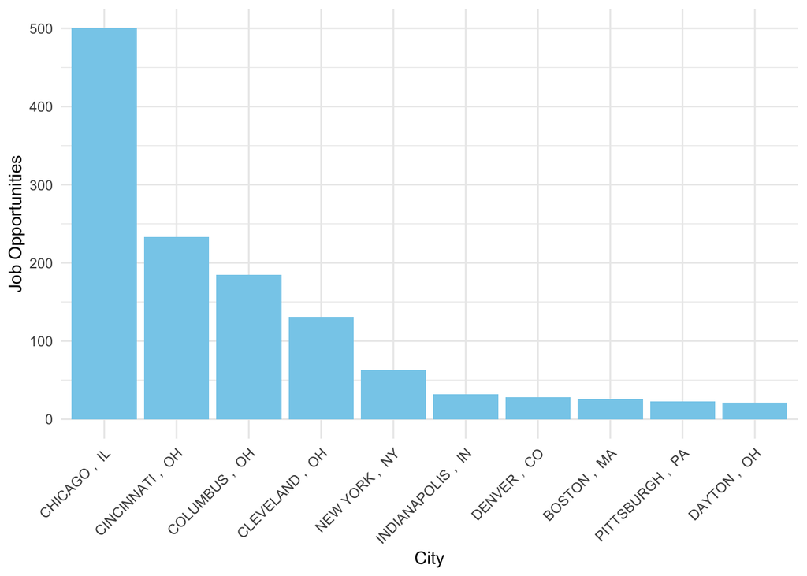

## 7.2 Column

```r
library(mapview)
library(sf)
city_map_df = data.frame(df_final$lng, df_final$lat, df_final$city_state)
city_map_df = na.omit(city_map_df)
city_map_sdf = st_as_sf(city_map_df,
                        coords=c("df_final.lng", "df_final.lat"), crs=4326)
mapview(city_map_sdf, label=city_map_sdf$city_state)
```

[interactive chart not shown]

```r
library(leaflet)

# Create a leaflet map for the top 10 cities
m <- leaflet(data = city_map_df) %>%
  addTiles() %>%
  setView(lng = -98, lat = 39, zoom = 4) %>%
  addCircleMarkers(
    radius = 8,
    color = "blue",
    label = ~df_final.city_state,
    lat = ~df_final.lat,
    lng = ~df_final.lng,
    popup = ~paste("City:", df_final.city_state)
 )
m
```

[interactive chart not shown]

[session information not shown]